# Advanced Geovisualization Lab 01

Ryleigh Landstra

2022-11-03

# Assessing The Proximity Of Social Media Photos and Prarie Dog Mounds in Boulder,CO

##### For this lab, I used the dataset provided to create two maps and a chart that shows how close social media posters were to known prarie dog mounds in Boulder, CO. This data could give insight to both why people may be taking photos in this area, as well as be used to understand potential impacts of park visitors on local wildlife.

**Step 1** Read in necessary packages.

```r
library(sf)
```

```r
library(ggplot2)
library(dplyr)
library(ggspatial)
library(tmap)
library(viridis)
```

**Step 2** Bring in the Boulder dataset into rMarkdown document.

```r
boulder <- st_read("C:/Users/rylan/Desktop/EAS 648/Lab01")
```

**Step 3** Filter the Boulder data to create new object.  
*Here, I filtered for only data points that represented social media photo locations.*

```r
filterboulder <- boulder %>%
  filter(DB ==  'Pano' | DB == 'Flickr')
```

**Step 4** Create visualization of social media photo locations using ggplot.  
*This code uses both the ‘boulder’ and ‘filterboulder’ objects to create a map that shows the ‘boulder’ spatial extent and the ‘filterboulder’ data points.*  
*Specifications are made to the color palette using ‘scale_color_brewer’, as well as the addition of a title, scale bar, and north arrow.*

```r
summary(filterboulder$DB)
```

```
##    Length     Class      Mode
##      6875 character character
```

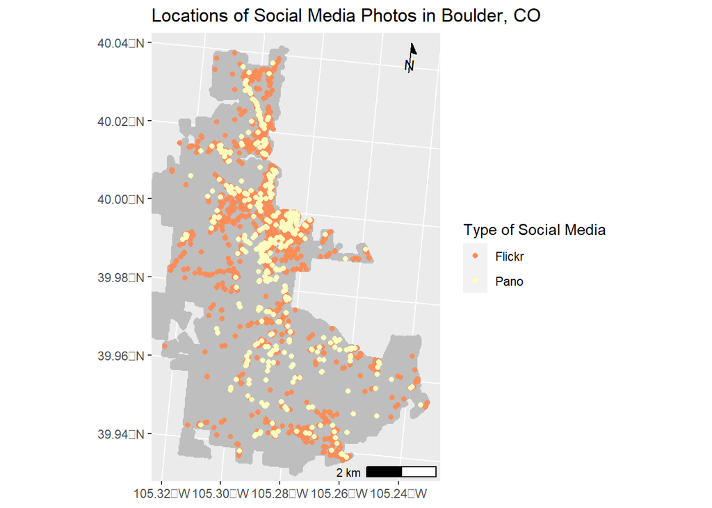

```r
p <- ggplot() +
  annotation_spatial(boulder, color = "grey") +
  layer_spatial(filterboulder, aes(col = DB)) +
  labs(colour = "Type of Social Media") +
  ggtitle("Locations of Social Media Photos in Boulder, CO") +
  annotation_north_arrow( height = unit(.75, "cm"),
  width = unit(1, "cm"),
  pad_x = unit(0.25, "cm"),
  pad_y = unit(0.25, "cm"),
  rotation = NULL,
  which_north = "true",
  location = "tr",
  style = north_arrow_minimal) +
  annotation_scale(location = "br",
                   pad_x = unit(0.1, "cm"),
                   pad_y = unit(0.1, "cm"))

p + scale_color_brewer(palette = "RdYlGn")
```

**We now have a map of all Flickr and Panramio photo locations within the data extent.**  
**Step 5** Create a visualization of photo locations symbolized based on the distance to prarie dog mounds.  
*This code uses two layers: ‘boulder’ to create the data extent, and ‘filterboulder’ to plot photo locations. As above, a scale bar, north arrow, and title were added.*

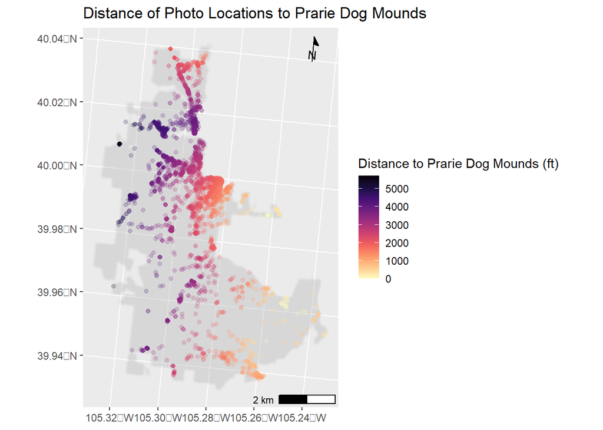

```r
ggplot() +
  geom_sf(data=boulder, fill = NA, alpha = .02, color = "grey") +
    geom_sf(data = filterboulder, aes(color=PrarDg_Dis),
    fill = NA, alpha = .2) +
    scale_colour_gradientn(colours = rev(magma(10))) +
  ggtitle("Distance of Photo Locations to Prarie Dog Mounds") +
  labs(colour = "Distance to Prarie Dog Mounds (ft)") +
    annotation_north_arrow( height = unit(.75, "cm"),
  width = unit(1, "cm"),
  pad_x = unit(0.25, "cm"),
  pad_y = unit(0.25, "cm"),
  rotation = NULL,
  which_north = "true",
  location = "tr",
  style = north_arrow_minimal) +
  annotation_scale(location = "br",
                   pad_x = unit(0.1, "cm"),
                   pad_y = unit(0.1, "cm"))
```

**We now have a map showing where social media photos were taken near known prarie dog mounds**  
**Step 6** Create a histogram summarizing the distance of photo locations to prarie dog mounds  
*This code uses the ‘PrarDG_Dis’ variable and the created ‘filterboulder’ object to show the count of photos at different distances from known prarie dog mounds*  
*geom_histogram is used here to create the chart, with alterations to the binwidth, color, title, and axis titles*

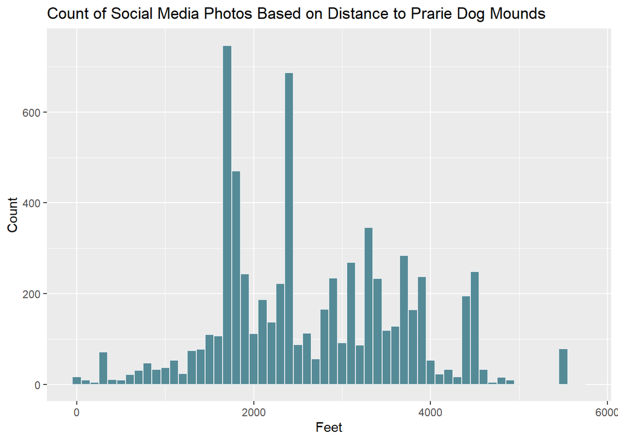

```r
  ggplot(filterboulder, aes(x=PrarDg_Dis)) +
  geom_histogram(binwidth=100, fill="#45818e", color="#e9ecef", alpha=0.9) +
  ggtitle( "Count of Social Media Photos Based on Distance to Prarie Dog Mounds") +
  labs(y= "Count", x = "Feet")
```

**We end this analysis with a histogram that shows the counts of photos taken from 0 to 6000 feet from prarie dog mounds.**